# Risk Factor Analysis

## Outcome Variable

**Outcome Variable:** swasted

## Predictor Variables

**Intervention Variable:** birthwt

**Adjustment Set:**

- arm
- sex
- W_mage
- meducyrs
- feducyrs
- vagbrth
- single
- brthmon
- W_parity
- delta_W_mage
- delta_meducyrs
- delta_feducyrs
- delta_vagbrth
- delta_single
- delta_brthmon
- delta_W_parity

## Stratifying Variables

The analysis was stratified on these variable(s):

- agecat
- studyid
- country

## Data Summary

| agecat | studyid | country | birthwt | swasted | n_cell | n |
| --- | --- | --- | --- | --- | --- | --- |
| Birth | CMC-V-BCS-2002 | INDIA | Normal or high birthweight | 0 | 76 | 86 |
| Birth | CMC-V-BCS-2002 | INDIA | Normal or high birthweight | 1 | 0 | 86 |
| Birth | CMC-V-BCS-2002 | INDIA | Low birthweight | 0 | 9 | 86 |
| Birth | CMC-V-BCS-2002 | INDIA | Low birthweight | 1 | 1 | 86 |
| Birth | CMIN | BANGLADESH | Normal or high birthweight | 0 | 14 | 19 |
| Birth | CMIN | BANGLADESH | Normal or high birthweight | 1 | 0 | 19 |
| Birth | CMIN | BANGLADESH | Low birthweight | 0 | 4 | 19 |
| Birth | CMIN | BANGLADESH | Low birthweight | 1 | 1 | 19 |
| Birth | COHORTS | GUATEMALA | Normal or high birthweight | 0 | 660 | 756 |
| Birth | COHORTS | GUATEMALA | Normal or high birthweight | 1 | 42 | 756 |
| Birth | COHORTS | GUATEMALA | Low birthweight | 0 | 36 | 756 |
| Birth | COHORTS | GUATEMALA | Low birthweight | 1 | 18 | 756 |
| Birth | COHORTS | INDIA | Normal or high birthweight | 0 | 5079 | 6193 |
| Birth | COHORTS | INDIA | Normal or high birthweight | 1 | 99 | 6193 |
| Birth | COHORTS | INDIA | Low birthweight | 0 | 794 | 6193 |
| Birth | COHORTS | INDIA | Low birthweight | 1 | 221 | 6193 |
| Birth | COHORTS | PHILIPPINES | Normal or high birthweight | 0 | 2623 | 2899 |
| Birth | COHORTS | PHILIPPINES | Normal or high birthweight | 1 | 65 | 2899 |
| Birth | COHORTS | PHILIPPINES | Low birthweight | 0 | 155 | 2899 |
| Birth | COHORTS | PHILIPPINES | Low birthweight | 1 | 56 | 2899 |
| Birth | CONTENT | PERU | Normal or high birthweight | 0 | 2 | 2 |
| Birth | CONTENT | PERU | Normal or high birthweight | 1 | 0 | 2 |
| Birth | CONTENT | PERU | Low birthweight | 0 | 0 | 2 |
| Birth | CONTENT | PERU | Low birthweight | 1 | 0 | 2 |
| Birth | EE | PAKISTAN | Normal or high birthweight | 0 | 135 | 177 |
| Birth | EE | PAKISTAN | Normal or high birthweight | 1 | 3 | 177 |
| Birth | EE | PAKISTAN | Low birthweight | 0 | 36 | 177 |
| Birth | EE | PAKISTAN | Low birthweight | 1 | 3 | 177 |
| Birth | GMS-Nepal | NEPAL | Normal or high birthweight | 0 | 467 | 641 |
| Birth | GMS-Nepal | NEPAL | Normal or high birthweight | 1 | 5 | 641 |

[output cut: 282 more lines]

The following strata were considered:

- agecat: 24 months, studyid: CMC-V-BCS-2002, country: INDIA
- agecat: 24 months, studyid: CMIN, country: BANGLADESH
- agecat: 24 months, studyid: COHORTS, country: GUATEMALA
- agecat: 24 months, studyid: COHORTS, country: INDIA
- agecat: 24 months, studyid: COHORTS, country: PHILIPPINES
- agecat: 24 months, studyid: CONTENT, country: PERU
- agecat: 24 months, studyid: EE, country: PAKISTAN
- agecat: 24 months, studyid: GMS-Nepal, country: NEPAL
- agecat: 24 months, studyid: IRC, country: INDIA
- agecat: 24 months, studyid: JiVitA-3, country: BANGLADESH
- agecat: 24 months, studyid: JiVitA-4, country: BANGLADESH
- agecat: 24 months, studyid: Keneba, country: GAMBIA
- agecat: 24 months, studyid: MAL-ED, country: BANGLADESH
- agecat: 24 months, studyid: MAL-ED, country: BRAZIL
- agecat: 24 months, studyid: MAL-ED, country: INDIA
- agecat: 24 months, studyid: MAL-ED, country: NEPAL
- agecat: 24 months, studyid: MAL-ED, country: PERU
- agecat: 24 months, studyid: MAL-ED, country: SOUTH AFRICA
- agecat: 24 months, studyid: MAL-ED, country: TANZANIA, UNITED REPUBLIC OF
- agecat: 24 months, studyid: NIH-Birth, country: BANGLADESH
- agecat: 24 months, studyid: NIH-Crypto, country: BANGLADESH
- agecat: 24 months, studyid: PROBIT, country: BELARUS
- agecat: 24 months, studyid: PROVIDE, country: BANGLADESH
- agecat: 24 months, studyid: TanzaniaChild2, country: TANZANIA, UNITED REPUBLIC OF
- agecat: 24 months, studyid: ZVITAMBO, country: ZIMBABWE
- agecat: 6 months, studyid: CMC-V-BCS-2002, country: INDIA
- agecat: 6 months, studyid: CMIN, country: BANGLADESH
- agecat: 6 months, studyid: COHORTS, country: GUATEMALA
- agecat: 6 months, studyid: COHORTS, country: INDIA
- agecat: 6 months, studyid: COHORTS, country: PHILIPPINES
- agecat: 6 months, studyid: CONTENT, country: PERU
- agecat: 6 months, studyid: EE, country: PAKISTAN
- agecat: 6 months, studyid: GMS-Nepal, country: NEPAL
- agecat: 6 months, studyid: IRC, country: INDIA
- agecat: 6 months, studyid: JiVitA-3, country: BANGLADESH
- agecat: 6 months, studyid: JiVitA-4, country: BANGLADESH
- agecat: 6 months, studyid: Keneba, country: GAMBIA
- agecat: 6 months, studyid: MAL-ED, country: BANGLADESH
- agecat: 6 months, studyid: MAL-ED, country: BRAZIL
- agecat: 6 months, studyid: MAL-ED, country: INDIA
- agecat: 6 months, studyid: MAL-ED, country: NEPAL
- agecat: 6 months, studyid: MAL-ED, country: PERU
- agecat: 6 months, studyid: MAL-ED, country: SOUTH AFRICA
- agecat: 6 months, studyid: MAL-ED, country: TANZANIA, UNITED REPUBLIC OF
- agecat: 6 months, studyid: NIH-Birth, country: BANGLADESH
- agecat: 6 months, studyid: NIH-Crypto, country: BANGLADESH
- agecat: 6 months, studyid: PROBIT, country: BELARUS
- agecat: 6 months, studyid: PROVIDE, country: BANGLADESH
- agecat: 6 months, studyid: ResPak, country: PAKISTAN
- agecat: 6 months, studyid: SAS-CompFeed, country: INDIA
- agecat: 6 months, studyid: TanzaniaChild2, country: TANZANIA, UNITED REPUBLIC OF
- agecat: 6 months, studyid: ZVITAMBO, country: ZIMBABWE
- agecat: Birth, studyid: CMC-V-BCS-2002, country: INDIA
- agecat: Birth, studyid: CMIN, country: BANGLADESH
- agecat: Birth, studyid: COHORTS, country: GUATEMALA
- agecat: Birth, studyid: COHORTS, country: INDIA
- agecat: Birth, studyid: COHORTS, country: PHILIPPINES
- agecat: Birth, studyid: CONTENT, country: PERU
- agecat: Birth, studyid: EE, country: PAKISTAN
- agecat: Birth, studyid: GMS-Nepal, country: NEPAL
- agecat: Birth, studyid: IRC, country: INDIA
- agecat: Birth, studyid: JiVitA-3, country: BANGLADESH
- agecat: Birth, studyid: JiVitA-4, country: BANGLADESH
- agecat: Birth, studyid: Keneba, country: GAMBIA
- agecat: Birth, studyid: MAL-ED, country: BANGLADESH
- agecat: Birth, studyid: MAL-ED, country: BRAZIL
- agecat: Birth, studyid: MAL-ED, country: INDIA
- agecat: Birth, studyid: MAL-ED, country: NEPAL
- agecat: Birth, studyid: MAL-ED, country: PERU
- agecat: Birth, studyid: MAL-ED, country: SOUTH AFRICA
- agecat: Birth, studyid: MAL-ED, country: TANZANIA, UNITED REPUBLIC OF
- agecat: Birth, studyid: NIH-Birth, country: BANGLADESH
- agecat: Birth, studyid: NIH-Crypto, country: BANGLADESH
- agecat: Birth, studyid: PROBIT, country: BELARUS
- agecat: Birth, studyid: PROVIDE, country: BANGLADESH
- agecat: Birth, studyid: ResPak, country: PAKISTAN
- agecat: Birth, studyid: SAS-CompFeed, country: INDIA
- agecat: Birth, studyid: ZVITAMBO, country: ZIMBABWE

### Dropped Strata

Some strata were dropped due to rare outcomes:

- agecat: Birth, studyid: CMC-V-BCS-2002, country: INDIA
- agecat: Birth, studyid: CMIN, country: BANGLADESH
- agecat: Birth, studyid: CONTENT, country: PERU
- agecat: Birth, studyid: EE, country: PAKISTAN
- agecat: Birth, studyid: JiVitA-4, country: BANGLADESH
- agecat: Birth, studyid: MAL-ED, country: BANGLADESH
- agecat: Birth, studyid: MAL-ED, country: BRAZIL
- agecat: Birth, studyid: MAL-ED, country: INDIA
- agecat: Birth, studyid: MAL-ED, country: NEPAL
- agecat: Birth, studyid: MAL-ED, country: PERU
- agecat: Birth, studyid: MAL-ED, country: SOUTH AFRICA
- agecat: Birth, studyid: MAL-ED, country: TANZANIA, UNITED REPUBLIC OF
- agecat: Birth, studyid: PROBIT, country: BELARUS
- agecat: Birth, studyid: PROVIDE, country: BANGLADESH
- agecat: Birth, studyid: ResPak, country: PAKISTAN
- agecat: Birth, studyid: SAS-CompFeed, country: INDIA
- agecat: 6 months, studyid: CMC-V-BCS-2002, country: INDIA
- agecat: 6 months, studyid: CMIN, country: BANGLADESH
- agecat: 6 months, studyid: COHORTS, country: GUATEMALA
- agecat: 6 months, studyid: CONTENT, country: PERU
- agecat: 6 months, studyid: GMS-Nepal, country: NEPAL
- agecat: 6 months, studyid: MAL-ED, country: BANGLADESH
- agecat: 6 months, studyid: MAL-ED, country: BRAZIL
- agecat: 6 months, studyid: MAL-ED, country: INDIA
- agecat: 6 months, studyid: MAL-ED, country: NEPAL
- agecat: 6 months, studyid: MAL-ED, country: PERU
- agecat: 6 months, studyid: MAL-ED, country: SOUTH AFRICA
- agecat: 6 months, studyid: MAL-ED, country: TANZANIA, UNITED REPUBLIC OF
- agecat: 6 months, studyid: NIH-Birth, country: BANGLADESH
- agecat: 6 months, studyid: NIH-Crypto, country: BANGLADESH
- agecat: 6 months, studyid: PROBIT, country: BELARUS
- agecat: 6 months, studyid: PROVIDE, country: BANGLADESH
- agecat: 6 months, studyid: ResPak, country: PAKISTAN
- agecat: 6 months, studyid: TanzaniaChild2, country: TANZANIA, UNITED REPUBLIC OF
- agecat: 24 months, studyid: CMC-V-BCS-2002, country: INDIA
- agecat: 24 months, studyid: CMIN, country: BANGLADESH
- agecat: 24 months, studyid: COHORTS, country: GUATEMALA
- agecat: 24 months, studyid: COHORTS, country: PHILIPPINES
- agecat: 24 months, studyid: CONTENT, country: PERU
- agecat: 24 months, studyid: EE, country: PAKISTAN
- agecat: 24 months, studyid: GMS-Nepal, country: NEPAL
- agecat: 24 months, studyid: IRC, country: INDIA
- agecat: 24 months, studyid: MAL-ED, country: BANGLADESH
- agecat: 24 months, studyid: MAL-ED, country: BRAZIL
- agecat: 24 months, studyid: MAL-ED, country: INDIA
- agecat: 24 months, studyid: MAL-ED, country: NEPAL
- agecat: 24 months, studyid: MAL-ED, country: PERU
- agecat: 24 months, studyid: MAL-ED, country: SOUTH AFRICA
- agecat: 24 months, studyid: MAL-ED, country: TANZANIA, UNITED REPUBLIC OF
- agecat: 24 months, studyid: NIH-Birth, country: BANGLADESH
- agecat: 24 months, studyid: NIH-Crypto, country: BANGLADESH
- agecat: 24 months, studyid: PROBIT, country: BELARUS
- agecat: 24 months, studyid: PROVIDE, country: BANGLADESH
- agecat: 24 months, studyid: TanzaniaChild2, country: TANZANIA, UNITED REPUBLIC OF

## Methods Detail

We’re interested in the causal parameters $E[Y_a]$ for all values of $a \in \mathcal{A}$. These parameters represent the mean outcome if, possibly contrary to fact, we intervened to set all units to have $A=a$. Under the randomization and positivity assumptions, these are identified by the statistical parameters $\psi_a=E_W[E_{Y|A,W}(Y|A=a,W)]$. In addition, we’re interested in the mean of $Y$, $E[Y]$ under no intervention (the observed mean). We will estimate these parameters by using SuperLearner to fit the relevant likelihood factors – $E_{Y|A,W}(Y|A=a,W)$ and $p(A=a|W)$, and then updating our likelihood fit using a joint TMLE.

For unadjusted analyses ($W=\{\}$), initial likelihoods were estimated using Lrnr_glm to estimate the simple $E(Y|A)$ and Lrnr_mean to estimate $p(A)$. For adjusted analyses, a small library containing Lrnr_glmnet, Lrnr_xgboost, and Lrnr_mean was used.

Having estimated these parameters, we will then use the delta method to estimate relative risks and attributable risks relative to a prespecified baseline level of $A$.

# Results Detail

## Results Plots

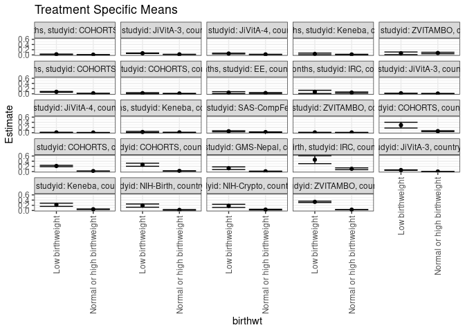

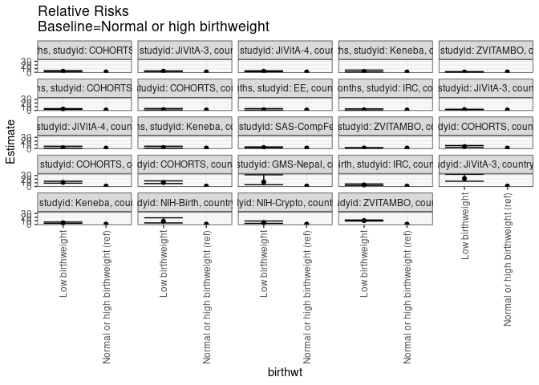

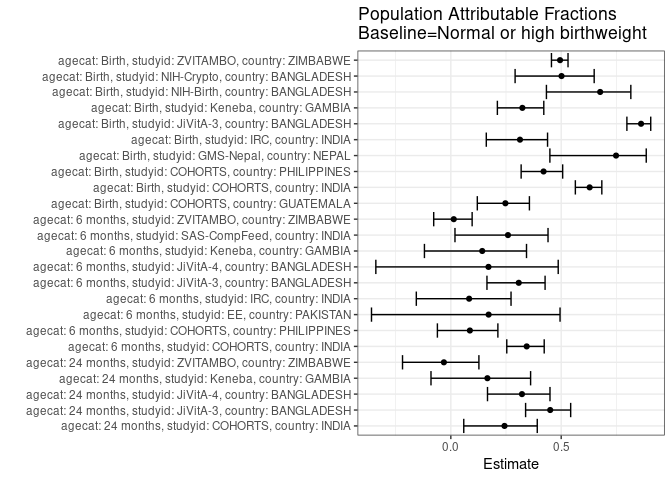

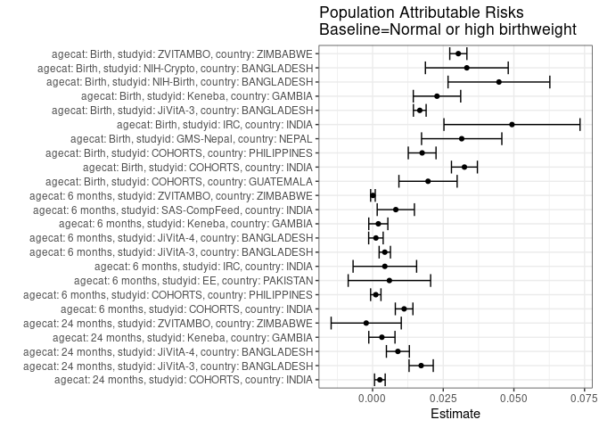

## Results Table

### Parameter: TSM

| agecat | studyid | country | intervention_level | baseline_level | estimate | ci_lower | ci_upper |
| --- | --- | --- | --- | --- | --- | --- | --- |
| Birth | COHORTS | GUATEMALA | Normal or high birthweight | NA | 0.0597469 | 0.0421720 | 0.0773217 |
| Birth | COHORTS | GUATEMALA | Low birthweight | NA | 0.2910024 | 0.1801873 | 0.4018175 |
| Birth | COHORTS | INDIA | Normal or high birthweight | NA | 0.0191758 | 0.0154345 | 0.0229171 |
| Birth | COHORTS | INDIA | Low birthweight | NA | 0.2157116 | 0.1902892 | 0.2411340 |
| Birth | COHORTS | PHILIPPINES | Normal or high birthweight | NA | 0.0242008 | 0.0183868 | 0.0300149 |
| Birth | COHORTS | PHILIPPINES | Low birthweight | NA | 0.2640766 | 0.2049428 | 0.3232103 |
| Birth | GMS-Nepal | NEPAL | Normal or high birthweight | NA | 0.0105932 | 0.0013501 | 0.0198363 |
| Birth | GMS-Nepal | NEPAL | Low birthweight | NA | 0.1301775 | 0.0794052 | 0.1809498 |
| Birth | IRC | INDIA | Normal or high birthweight | NA | 0.1081090 | 0.0726752 | 0.1435429 |
| Birth | IRC | INDIA | Low birthweight | NA | 0.4577019 | 0.3047592 | 0.6106446 |
| Birth | JiVitA-3 | BANGLADESH | Normal or high birthweight | NA | 0.0026781 | 0.0015829 | 0.0037733 |
| Birth | JiVitA-3 | BANGLADESH | Low birthweight | NA | 0.0580752 | 0.0507023 | 0.0654481 |
| Birth | Keneba | GAMBIA | Normal or high birthweight | NA | 0.0475175 | 0.0358341 | 0.0592008 |
| Birth | Keneba | GAMBIA | Low birthweight | NA | 0.2193126 | 0.1580894 | 0.2805358 |
| Birth | NIH-Birth | BANGLADESH | Normal or high birthweight | NA | 0.0213777 | 0.0075492 | 0.0352061 |
| Birth | NIH-Birth | BANGLADESH | Low birthweight | NA | 0.1883117 | 0.1265102 | 0.2501132 |
| Birth | NIH-Crypto | BANGLADESH | Normal or high birthweight | NA | 0.0331396 | 0.0180987 | 0.0481804 |
| Birth | NIH-Crypto | BANGLADESH | Low birthweight | NA | 0.1777784 | 0.1173090 | 0.2382478 |
| Birth | ZVITAMBO | ZIMBABWE | Normal or high birthweight | NA | 0.0309766 | 0.0278236 | 0.0341296 |
| Birth | ZVITAMBO | ZIMBABWE | Low birthweight | NA | 0.3330106 | 0.3072341 | 0.3587871 |
| 6 months | COHORTS | INDIA | Normal or high birthweight | NA | 0.0213108 | 0.0173000 | 0.0253215 |
| 6 months | COHORTS | INDIA | Low birthweight | NA | 0.0757928 | 0.0607557 | 0.0908300 |
| 6 months | COHORTS | PHILIPPINES | Normal or high birthweight | NA | 0.0120033 | 0.0076601 | 0.0163465 |
| 6 months | COHORTS | PHILIPPINES | Low birthweight | NA | 0.0241935 | 0.0050671 | 0.0433200 |
| 6 months | EE | PAKISTAN | Normal or high birthweight | NA | 0.0288066 | 0.0077482 | 0.0498650 |
| 6 months | EE | PAKISTAN | Low birthweight | NA | 0.0458015 | 0.0099545 | 0.0816486 |
| 6 months | IRC | INDIA | Normal or high birthweight | NA | 0.0479042 | 0.0249721 | 0.0708362 |
| 6 months | IRC | INDIA | Low birthweight | NA | 0.0735294 | 0.0114167 | 0.1356422 |
| 6 months | JiVitA-3 | BANGLADESH | Normal or high birthweight | NA | 0.0097175 | 0.0073946 | 0.0120404 |
| 6 months | JiVitA-3 | BANGLADESH | Low birthweight | NA | 0.0204432 | 0.0161234 | 0.0247629 |
| 6 months | JiVitA-4 | BANGLADESH | Normal or high birthweight | NA | 0.0057414 | 0.0003313 | 0.0111515 |
| 6 months | JiVitA-4 | BANGLADESH | Low birthweight | NA | 0.0099453 | 0.0022014 | 0.0176892 |
| 6 months | Keneba | GAMBIA | Normal or high birthweight | NA | 0.0122164 | 0.0058540 | 0.0185788 |
| 6 months | Keneba | GAMBIA | Low birthweight | NA | 0.0265957 | 0.0035874 | 0.0496041 |
| 6 months | SAS-CompFeed | INDIA | Normal or high birthweight | NA | 0.0235074 | 0.0139665 | 0.0330483 |
| 6 months | SAS-CompFeed | INDIA | Low birthweight | NA | 0.0552490 | 0.0354101 | 0.0750880 |
| 6 months | ZVITAMBO | ZIMBABWE | Normal or high birthweight | NA | 0.0091996 | 0.0070246 | 0.0113745 |
| 6 months | ZVITAMBO | ZIMBABWE | Low birthweight | NA | 0.0103159 | 0.0043387 | 0.0162931 |
| 24 months | COHORTS | INDIA | Normal or high birthweight | NA | 0.0080062 | 0.0052091 | 0.0108033 |
| 24 months | COHORTS | INDIA | Low birthweight | NA | 0.0222337 | 0.0126038 | 0.0318637 |
| 24 months | JiVitA-3 | BANGLADESH | Normal or high birthweight | NA | 0.0209884 | 0.0162222 | 0.0257547 |
| 24 months | JiVitA-3 | BANGLADESH | Low birthweight | NA | 0.0635077 | 0.0541933 | 0.0728221 |
| 24 months | JiVitA-4 | BANGLADESH | Normal or high birthweight | NA | 0.0188200 | 0.0128308 | 0.0248091 |
| 24 months | JiVitA-4 | BANGLADESH | Low birthweight | NA | 0.0523237 | 0.0379108 | 0.0667365 |
| 24 months | Keneba | GAMBIA | Normal or high birthweight | NA | 0.0165746 | 0.0082527 | 0.0248965 |
| 24 months | Keneba | GAMBIA | Low birthweight | NA | 0.0394737 | 0.0085037 | 0.0704436 |
| 24 months | ZVITAMBO | ZIMBABWE | Normal or high birthweight | NA | 0.0741840 | 0.0461713 | 0.1021967 |
| 24 months | ZVITAMBO | ZIMBABWE | Low birthweight | NA | 0.0638298 | 0.0143557 | 0.1133039 |

### Parameter: E(Y)

| agecat | studyid | country | intervention_level | baseline_level | estimate | ci_lower | ci_upper |
| --- | --- | --- | --- | --- | --- | --- | --- |
| Birth | COHORTS | GUATEMALA | NA | NA | 0.0793651 | 0.0600839 | 0.0986462 |
| Birth | COHORTS | INDIA | NA | NA | 0.0516712 | 0.0461576 | 0.0571849 |
| Birth | COHORTS | PHILIPPINES | NA | NA | 0.0417385 | 0.0344572 | 0.0490198 |
| Birth | GMS-Nepal | NEPAL | NA | NA | 0.0421217 | 0.0265597 | 0.0576837 |
| Birth | IRC | INDIA | NA | NA | 0.1574344 | 0.1188345 | 0.1960344 |
| Birth | JiVitA-3 | BANGLADESH | NA | NA | 0.0193738 | 0.0169653 | 0.0217823 |
| Birth | Keneba | GAMBIA | NA | NA | 0.0703072 | 0.0572109 | 0.0834034 |
| Birth | NIH-Birth | BANGLADESH | NA | NA | 0.0660870 | 0.0457632 | 0.0864107 |
| Birth | NIH-Crypto | BANGLADESH | NA | NA | 0.0664781 | 0.0481022 | 0.0848539 |
| Birth | ZVITAMBO | ZIMBABWE | NA | NA | 0.0613145 | 0.0571772 | 0.0654519 |
| 6 months | COHORTS | INDIA | NA | NA | 0.0324696 | 0.0280758 | 0.0368634 |
| 6 months | COHORTS | PHILIPPINES | NA | NA | 0.0131381 | 0.0088134 | 0.0174629 |
| 6 months | EE | PAKISTAN | NA | NA | 0.0347594 | 0.0161707 | 0.0533480 |
| 6 months | IRC | INDIA | NA | NA | 0.0522388 | 0.0304606 | 0.0740170 |
| 6 months | JiVitA-3 | BANGLADESH | NA | NA | 0.0140376 | 0.0118094 | 0.0162658 |
| 6 months | JiVitA-4 | BANGLADESH | NA | NA | 0.0069221 | 0.0024171 | 0.0114272 |
| 6 months | Keneba | GAMBIA | NA | NA | 0.0142429 | 0.0078820 | 0.0206038 |
| 6 months | SAS-CompFeed | INDIA | NA | NA | 0.0317221 | 0.0237601 | 0.0396840 |
| 6 months | ZVITAMBO | ZIMBABWE | NA | NA | 0.0093237 | 0.0072772 | 0.0113703 |
| 24 months | COHORTS | INDIA | NA | NA | 0.0105787 | 0.0076905 | 0.0134669 |
| 24 months | JiVitA-3 | BANGLADESH | NA | NA | 0.0381763 | 0.0335656 | 0.0427871 |
| 24 months | JiVitA-4 | BANGLADESH | NA | NA | 0.0277708 | 0.0219080 | 0.0336336 |
| 24 months | Keneba | GAMBIA | NA | NA | 0.0198675 | 0.0114511 | 0.0282840 |
| 24 months | ZVITAMBO | ZIMBABWE | NA | NA | 0.0719258 | 0.0475057 | 0.0963459 |

### Parameter: RR

| agecat | studyid | country | intervention_level | baseline_level | estimate | ci_lower | ci_upper |
| --- | --- | --- | --- | --- | --- | --- | --- |
| Birth | COHORTS | GUATEMALA | Normal or high birthweight | Normal or high birthweight | 1.0000000 | 1.0000000 | 1.000000 |
| Birth | COHORTS | GUATEMALA | Low birthweight | Normal or high birthweight | 4.8705896 | 3.0124127 | 7.874964 |
| Birth | COHORTS | INDIA | Normal or high birthweight | Normal or high birthweight | 1.0000000 | 1.0000000 | 1.000000 |
| Birth | COHORTS | INDIA | Low birthweight | Normal or high birthweight | 11.2491503 | 8.9563251 | 14.128940 |
| Birth | COHORTS | PHILIPPINES | Normal or high birthweight | Normal or high birthweight | 1.0000000 | 1.0000000 | 1.000000 |
| Birth | COHORTS | PHILIPPINES | Low birthweight | Normal or high birthweight | 10.9118818 | 7.8583991 | 15.151835 |
| Birth | GMS-Nepal | NEPAL | Normal or high birthweight | Normal or high birthweight | 1.0000000 | 1.0000000 | 1.000000 |
| Birth | GMS-Nepal | NEPAL | Low birthweight | Normal or high birthweight | 12.2887574 | 4.7253145 | 31.958414 |
| Birth | IRC | INDIA | Normal or high birthweight | Normal or high birthweight | 1.0000000 | 1.0000000 | 1.000000 |
| Birth | IRC | INDIA | Low birthweight | Normal or high birthweight | 4.2337059 | 2.6479109 | 6.769210 |
| Birth | JiVitA-3 | BANGLADESH | Normal or high birthweight | Normal or high birthweight | 1.0000000 | 1.0000000 | 1.000000 |
| Birth | JiVitA-3 | BANGLADESH | Low birthweight | Normal or high birthweight | 21.6855334 | 14.2071525 | 33.100395 |
| Birth | Keneba | GAMBIA | Normal or high birthweight | Normal or high birthweight | 1.0000000 | 1.0000000 | 1.000000 |
| Birth | Keneba | GAMBIA | Low birthweight | Normal or high birthweight | 4.6154094 | 3.1786928 | 6.701498 |
| Birth | NIH-Birth | BANGLADESH | Normal or high birthweight | Normal or high birthweight | 1.0000000 | 1.0000000 | 1.000000 |
| Birth | NIH-Birth | BANGLADESH | Low birthweight | Normal or high birthweight | 8.8088023 | 4.2648085 | 18.194252 |
| Birth | NIH-Crypto | BANGLADESH | Normal or high birthweight | Normal or high birthweight | 1.0000000 | 1.0000000 | 1.000000 |
| Birth | NIH-Crypto | BANGLADESH | Low birthweight | Normal or high birthweight | 5.3645344 | 3.0437072 | 9.454992 |
| Birth | ZVITAMBO | ZIMBABWE | Normal or high birthweight | Normal or high birthweight | 1.0000000 | 1.0000000 | 1.000000 |
| Birth | ZVITAMBO | ZIMBABWE | Low birthweight | Normal or high birthweight | 10.7503919 | 9.4595262 | 12.217412 |
| 6 months | COHORTS | INDIA | Normal or high birthweight | Normal or high birthweight | 1.0000000 | 1.0000000 | 1.000000 |
| 6 months | COHORTS | INDIA | Low birthweight | Normal or high birthweight | 3.5565522 | 2.7053925 | 4.675500 |
| 6 months | COHORTS | PHILIPPINES | Normal or high birthweight | Normal or high birthweight | 1.0000000 | 1.0000000 | 1.000000 |
| 6 months | COHORTS | PHILIPPINES | Low birthweight | Normal or high birthweight | 2.0155729 | 0.8449075 | 4.808259 |
| 6 months | EE | PAKISTAN | Normal or high birthweight | Normal or high birthweight | 1.0000000 | 1.0000000 | 1.000000 |
| 6 months | EE | PAKISTAN | Low birthweight | Normal or high birthweight | 1.5899673 | 0.5448486 | 4.639814 |
| 6 months | IRC | INDIA | Normal or high birthweight | Normal or high birthweight | 1.0000000 | 1.0000000 | 1.000000 |
| 6 months | IRC | INDIA | Low birthweight | Normal or high birthweight | 1.5349265 | 0.5813149 | 4.052880 |
| 6 months | JiVitA-3 | BANGLADESH | Normal or high birthweight | Normal or high birthweight | 1.0000000 | 1.0000000 | 1.000000 |
| 6 months | JiVitA-3 | BANGLADESH | Low birthweight | Normal or high birthweight | 2.1037427 | 1.5339461 | 2.885195 |
| 6 months | JiVitA-4 | BANGLADESH | Normal or high birthweight | Normal or high birthweight | 1.0000000 | 1.0000000 | 1.000000 |
| 6 months | JiVitA-4 | BANGLADESH | Low birthweight | Normal or high birthweight | 1.7322140 | 0.5078675 | 5.908166 |
| 6 months | Keneba | GAMBIA | Normal or high birthweight | Normal or high birthweight | 1.0000000 | 1.0000000 | 1.000000 |
| 6 months | Keneba | GAMBIA | Low birthweight | Normal or high birthweight | 2.1770517 | 0.7930960 | 5.976015 |
| 6 months | SAS-CompFeed | INDIA | Normal or high birthweight | Normal or high birthweight | 1.0000000 | 1.0000000 | 1.000000 |
| 6 months | SAS-CompFeed | INDIA | Low birthweight | Normal or high birthweight | 2.3502831 | 1.3066898 | 4.227347 |
| 6 months | ZVITAMBO | ZIMBABWE | Normal or high birthweight | Normal or high birthweight | 1.0000000 | 1.0000000 | 1.000000 |
| 6 months | ZVITAMBO | ZIMBABWE | Low birthweight | Normal or high birthweight | 1.1213422 | 0.5998080 | 2.096351 |
| 24 months | COHORTS | INDIA | Normal or high birthweight | Normal or high birthweight | 1.0000000 | 1.0000000 | 1.000000 |
| 24 months | COHORTS | INDIA | Low birthweight | Normal or high birthweight | 2.7770702 | 1.5922462 | 4.843547 |
| 24 months | JiVitA-3 | BANGLADESH | Normal or high birthweight | Normal or high birthweight | 1.0000000 | 1.0000000 | 1.000000 |
| 24 months | JiVitA-3 | BANGLADESH | Low birthweight | Normal or high birthweight | 3.0258411 | 2.3050385 | 3.972044 |
| 24 months | JiVitA-4 | BANGLADESH | Normal or high birthweight | Normal or high birthweight | 1.0000000 | 1.0000000 | 1.000000 |
| 24 months | JiVitA-4 | BANGLADESH | Low birthweight | Normal or high birthweight | 2.7802205 | 1.8358596 | 4.210358 |
| 24 months | Keneba | GAMBIA | Normal or high birthweight | Normal or high birthweight | 1.0000000 | 1.0000000 | 1.000000 |
| 24 months | Keneba | GAMBIA | Low birthweight | Normal or high birthweight | 2.3815789 | 0.9382768 | 6.045037 |
| 24 months | ZVITAMBO | ZIMBABWE | Normal or high birthweight | Normal or high birthweight | 1.0000000 | 1.0000000 | 1.000000 |
| 24 months | ZVITAMBO | ZIMBABWE | Low birthweight | Normal or high birthweight | 0.8604255 | 0.3633053 | 2.037769 |

### Parameter: PAR

| agecat | studyid | country | intervention_level | baseline_level | estimate | ci_lower | ci_upper |
| --- | --- | --- | --- | --- | --- | --- | --- |
| Birth | COHORTS | GUATEMALA | Normal or high birthweight | NA | 0.0196182 | 0.0093195 | 0.0299170 |
| Birth | COHORTS | INDIA | Normal or high birthweight | NA | 0.0324954 | 0.0279078 | 0.0370831 |
| Birth | COHORTS | PHILIPPINES | Normal or high birthweight | NA | 0.0175377 | 0.0126259 | 0.0224495 |
| Birth | GMS-Nepal | NEPAL | Normal or high birthweight | NA | 0.0315285 | 0.0173231 | 0.0457338 |
| Birth | IRC | INDIA | Normal or high birthweight | NA | 0.0493254 | 0.0252501 | 0.0734006 |
| Birth | JiVitA-3 | BANGLADESH | Normal or high birthweight | NA | 0.0166958 | 0.0144452 | 0.0189463 |
| Birth | Keneba | GAMBIA | Normal or high birthweight | NA | 0.0227897 | 0.0144024 | 0.0311769 |
| Birth | NIH-Birth | BANGLADESH | Normal or high birthweight | NA | 0.0447093 | 0.0267021 | 0.0627165 |
| Birth | NIH-Crypto | BANGLADESH | Normal or high birthweight | NA | 0.0333385 | 0.0186856 | 0.0479913 |
| Birth | ZVITAMBO | ZIMBABWE | Normal or high birthweight | NA | 0.0303379 | 0.0273060 | 0.0333698 |
| 6 months | COHORTS | INDIA | Normal or high birthweight | NA | 0.0111589 | 0.0080450 | 0.0142727 |
| 6 months | COHORTS | PHILIPPINES | Normal or high birthweight | NA | 0.0011348 | -0.0006960 | 0.0029656 |
| 6 months | EE | PAKISTAN | Normal or high birthweight | NA | 0.0059528 | -0.0086328 | 0.0205383 |
| 6 months | IRC | INDIA | Normal or high birthweight | NA | 0.0043346 | -0.0069046 | 0.0155739 |
| 6 months | JiVitA-3 | BANGLADESH | Normal or high birthweight | NA | 0.0043201 | 0.0023188 | 0.0063213 |
| 6 months | JiVitA-4 | BANGLADESH | Normal or high birthweight | NA | 0.0011807 | -0.0013841 | 0.0037455 |
| 6 months | Keneba | GAMBIA | Normal or high birthweight | NA | 0.0020265 | -0.0013485 | 0.0054014 |
| 6 months | SAS-CompFeed | INDIA | Normal or high birthweight | NA | 0.0082147 | 0.0016296 | 0.0147998 |
| 6 months | ZVITAMBO | ZIMBABWE | Normal or high birthweight | NA | 0.0001242 | -0.0006870 | 0.0009353 |
| 24 months | COHORTS | INDIA | Normal or high birthweight | NA | 0.0025725 | 0.0006887 | 0.0044563 |
| 24 months | JiVitA-3 | BANGLADESH | Normal or high birthweight | NA | 0.0171879 | 0.0129120 | 0.0214638 |
| 24 months | JiVitA-4 | BANGLADESH | Normal or high birthweight | NA | 0.0089509 | 0.0048895 | 0.0130122 |
| 24 months | Keneba | GAMBIA | Normal or high birthweight | NA | 0.0032930 | -0.0013440 | 0.0079299 |
| 24 months | ZVITAMBO | ZIMBABWE | Normal or high birthweight | NA | -0.0022582 | -0.0146646 | 0.0101481 |

### Parameter: PAF

| agecat | studyid | country | intervention_level | baseline_level | estimate | ci_lower | ci_upper |
| --- | --- | --- | --- | --- | --- | --- | --- |
| Birth | COHORTS | GUATEMALA | Normal or high birthweight | NA | 0.2471896 | 0.1199811 | 0.3560099 |
| Birth | COHORTS | INDIA | Normal or high birthweight | NA | 0.6288881 | 0.5641085 | 0.6840405 |
| Birth | COHORTS | PHILIPPINES | Normal or high birthweight | NA | 0.4201802 | 0.3185544 | 0.5066502 |
| Birth | GMS-Nepal | NEPAL | Normal or high birthweight | NA | 0.7485091 | 0.4487581 | 0.8852633 |
| Birth | IRC | INDIA | Normal or high birthweight | NA | 0.3133073 | 0.1606740 | 0.4381840 |
| Birth | JiVitA-3 | BANGLADESH | Normal or high birthweight | NA | 0.8617690 | 0.7976039 | 0.9055921 |
| Birth | Keneba | GAMBIA | Normal or high birthweight | NA | 0.3241445 | 0.2108664 | 0.4211619 |
| Birth | NIH-Birth | BANGLADESH | Normal or high birthweight | NA | 0.6765221 | 0.4330886 | 0.8154245 |
| Birth | NIH-Crypto | BANGLADESH | Normal or high birthweight | NA | 0.5014960 | 0.2911812 | 0.6494080 |
| Birth | ZVITAMBO | ZIMBABWE | Normal or high birthweight | NA | 0.4947920 | 0.4558758 | 0.5309248 |
| 6 months | COHORTS | INDIA | Normal or high birthweight | NA | 0.3436708 | 0.2534291 | 0.4230046 |
| 6 months | COHORTS | PHILIPPINES | Normal or high birthweight | NA | 0.0863765 | -0.0608389 | 0.2131625 |
| 6 months | EE | PAKISTAN | Normal or high birthweight | NA | 0.1712567 | -0.3593562 | 0.4947495 |
| 6 months | IRC | INDIA | Normal or high birthweight | NA | 0.0829769 | -0.1563338 | 0.2727607 |
| 6 months | JiVitA-3 | BANGLADESH | Normal or high birthweight | NA | 0.3077498 | 0.1636841 | 0.4269984 |
| 6 months | JiVitA-4 | BANGLADESH | Normal or high birthweight | NA | 0.1705721 | -0.3396783 | 0.4864807 |
| 6 months | Keneba | GAMBIA | Normal or high birthweight | NA | 0.1422798 | -0.1195459 | 0.3428729 |
| 6 months | SAS-CompFeed | INDIA | Normal or high birthweight | NA | 0.2589573 | 0.0188133 | 0.4403264 |
| 6 months | ZVITAMBO | ZIMBABWE | Normal or high birthweight | NA | 0.0133161 | -0.0775762 | 0.0965417 |
| 24 months | COHORTS | INDIA | Normal or high birthweight | NA | 0.2431798 | 0.0585977 | 0.3915705 |
| 24 months | JiVitA-3 | BANGLADESH | Normal or high birthweight | NA | 0.4502236 | 0.3387386 | 0.5429129 |
| 24 months | JiVitA-4 | BANGLADESH | Normal or high birthweight | NA | 0.3223117 | 0.1661425 | 0.4492327 |
| 24 months | Keneba | GAMBIA | Normal or high birthweight | NA | 0.1657459 | -0.0898431 | 0.3613943 |
| 24 months | ZVITAMBO | ZIMBABWE | Normal or high birthweight | NA | -0.0313966 | -0.2188193 | 0.1272054 |